# The Effect of Discounting and Same-Day Shipping on Profits

Thinh Mai

# How Could Advertising and Promotions Affect the Company in Sales and Revenue?

- Background
  - A sample of 9,994 observations on daily online orders
  - To be better effective and strategic to improve profitability
  - New variables created to help in analyzing the data set and providing recommendations
  - Cost = Revenue - Profit
  - Price = Revenue / Quantity
- The old saying “Time is Money” holds even more truth in today’s on demand economy
  - We are in a fast-moving era
  - same day delivery service occurs when goods are collected and delivered to customers within the same day
- Having reasonable discount offers could affect our company profit and sales targets in the long run
  - Increase value
  - Maintain brand reputation

# The Power of Same-Day Shipping on Profit

- Same-Day shipping Generated The Most Profit on Technology
  - same day ship mode raises the most profit our company simply because it meets the customer expectations
    - People are willing to pay more to get there orders as soon as possible
  - By offering a fast and same-day delivery, we attract the customers and encourage them to place an order
    - Explains why there is a boost in our profit on Technology across all segments

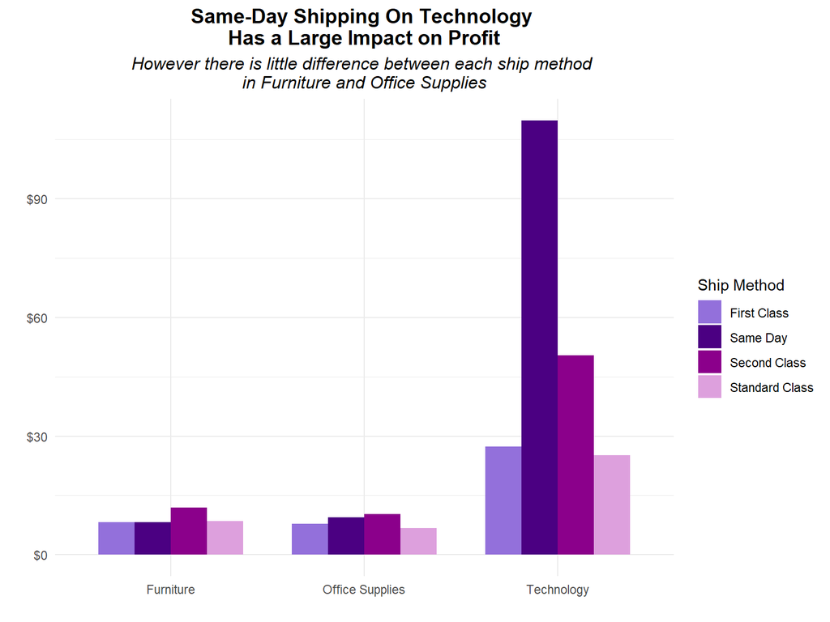